# Project Starter Scrape Code

Jessica Payne

#### Load Packages

```r
library(rvest)
library(tidyverse)
library(genius)
library(gridExtra)
```

#### Scrape and create table of records from 1980s, 1990s, 2000s, and 2010s

##### 1980s

```r
# read webpage for Grammy Awards
webpage <- read_html("https://en.wikipedia.org/wiki/Grammy_Award_for_Record_of_the_Year")

# copy xpath for table of 1980s
XPATH80 <- '/html/body/div[3]/div[3]/div[5]/div[1]/table[5]'

# run the following to create table of songs from 1980s
table_1980 <-
  webpage %>%
  html_nodes(xpath = XPATH80) %>%
  html_table(fill = TRUE)

d1980 <- table_1980[[1]]
```

```r
head(d1980)
```

|  | Year[I] | Record | Artist(s) | Production team |
| --- | --- | --- | --- | --- |
| 1 | 1980[44] | NA | NA | NA |
| 2 | 1980[44] | "What a Fool Believes" | The Doobie Brothers | Ted Templeman, producer |
| 3 | 1980[44] | "After the Love Has Gone" | Earth, Wind & Fire | Maurice White, producer |
| 4 | 1980[44] | "I Will Survive" | Gloria Gaynor | Freddie Perren & Dino Fekaris, producers |
| 5 | 1980[44] | "The Gambler" | Kenny Rogers | Larry Butler, producer |
| 6 | 1980[44] | "You Don't Bring Me Flowers" | Barbra Streisand & Neil Diamond | Bob Gaudio, producer |

##### 1990s

```r
XPATH90 <- '/html/body/div[3]/div[3]/div[5]/div[1]/table[6]'
#the xpath for each decade's table is determined by /table[n], each decade increases n by one

table_1990 <-
  webpage %>%
  html_nodes(xpath = XPATH90) %>%
  html_table(fill = TRUE)

d1990 <- table_1990[[1]]
```

```r
head(d1990)
```

|  | Year[I] | Record | Artist(s) | Production team |
| --- | --- | --- | --- | --- |
| 1 | 1990[54] | NA | NA | NA |
| 2 | 1990[54] | "Wind Beneath My Wings" | Bette Midler | Arif Mardin, producer |
| 3 | 1990[54] | "The End of the Innocence" | Don Henley | Don Henley & Bruce Hornsby, producers |
| 4 | 1990[54] | "She Drives Me Crazy" | Fine Young Cannibals | David Z & Fine Young Cannibals, producers |
| 5 | 1990[54] | "We Didn't Start the Fire" | Billy Joel | Mick Jones & Billy Joel, producers |
| 6 | 1990[54] | "The Living Years" | Mike + The Mechanics | Christopher Neil & Mike Rutherford, producers |

##### 2000s

```r
XPATH00 <- '/html/body/div[3]/div[3]/div[5]/div[1]/table[7]'

table_2000 <-
  webpage %>%
  html_nodes(xpath = XPATH00) %>%
  html_table(fill = TRUE)

d2000 <- table_2000[[1]]
```

```r
head(d2000)
```

|  | Year[I] | Record | Artist(s) | Production team |
| --- | --- | --- | --- | --- |
| 1 | 2000[64] | NA | NA | NA |
| 2 | 2000[64] | "Smooth" | Santana featuring Rob Thomas | Matt Serletic, producer; David Thoener, engineer/mixer |
| 3 | 2000[64] | "Believe" | Cher | Brian Rawling & Mark Taylor, producers; Mark Taylor, engineer/mixer |
| 4 | 2000[64] | "I Want It That Way" | Backstreet Boys | Kristian Lundin & Max Martin, producers; Kristian Lundin & Max Martin, engineers/mixers |
| 5 | 2000[64] | "Livin' la Vida Loca" | Ricky Martin | Desmond Child & Robi Rosa, producers; Charles Dye, engineer/mixer |
| 6 | 2000[64] | "No Scrubs" | TLC | Kevin "Shekspere" Briggs, producer; Leslie Brathwaite & Carlton Lynn, engineers/mixers |

##### 2010s

```r
XPATH10 <- '/html/body/div[3]/div[3]/div[5]/div[1]/table[8]'

table_2010 <-
  webpage %>%
  html_nodes(xpath = XPATH10) %>%
  html_table(fill = TRUE)

d2010 <- table_2010[[1]]
```

```r
head(d2010)
```

|  | Year[I] | Record | Artist(s) | Production team |
| --- | --- | --- | --- | --- |
| 1 | 2010[74] | NA | NA | NA |
| 2 | 2010[74] | "Use Somebody" | Kings of Leon | Jacquire King & Angelo Petraglia, producers; Jacquire King, engineer/mixer |
| 3 | 2010[74] | "Halo" | Beyoncé | Beyoncé Knowles & Ryan Tedder, producers; Jim Caruana, Mark "Spike" Stent & Ryan Tedder, engineers/mixers |
| 4 | 2010[74] | "I Gotta Feeling" | The Black Eyed Peas | David Guetta & Frederick Riesterer, producers; will.i.am, Dylan "3-D" Dresdow & Padraic "Padlock" Kerin, engineers/mixers |
| 5 | 2010[74] | "Poker Face" | Lady Gaga | RedOne, producer; Robert Orton, RedOne & Dave Russell, engineers/mixers |
| 6 | 2010[74] | "You Belong with Me" | Taylor Swift | Nathan Chapman & Taylor Swift, producers; Chad Carlson & Justin Niebank, engineers/mixers |

#### Cleaning footnotes

##### 1980s

```r
ROY80s <- #creating a new table for the cleaned 80s data
  d1980 %>%
  rename("year" = "Year[I]", "track" = "Record", "artist" = "Artist(s)") %>% #renaming the variables
  select(year, track, artist) %>% #removing the producers column
  mutate(year = gsub(pattern = "\\[44]|\\[45]|\\[46]|\\[47]|\\[48]|\\[49]|\\[50]|\\[51]|\\[52]|\\[53]", replacement = "", year)) %>% #removing the footnotes from the years
  drop_na() %>% #removing the rows with NA values
  add_genius(artist, track, type = "lyrics") #adding lyrics
```

| year | track | artist | track_title | line | lyric |
| --- | --- | --- | --- | --- | --- |
| 1980 | "What a Fool Believes" | The Doobie Brothers | What a Fool Believes | 1 | He came from somewhere back in her long ago |
| 1980 | "What a Fool Believes" | The Doobie Brothers | What a Fool Believes | 2 | The sentimental fool don't see |
| 1980 | "What a Fool Believes" | The Doobie Brothers | What a Fool Believes | 3 | Tryin' hard to recreate |
| 1980 | "What a Fool Believes" | The Doobie Brothers | What a Fool Believes | 4 | What had yet to be created once in her life |
| 1980 | "What a Fool Believes" | The Doobie Brothers | What a Fool Believes | 5 | She musters a smile for his nostalgic tale |
| 1980 | "What a Fool Believes" | The Doobie Brothers | What a Fool Believes | 6 | Never coming near what he wanted to say |

##### 1990s

```r
ROY90s <-
  d1990 %>%
  rename("year" = "Year[I]", "track" = "Record", "artist" = "Artist(s)") %>%
  select(year, track, artist) %>%
  mutate(year = gsub(pattern = "\\[54]|\\[55]|\\[56]|\\[57]|\\[58]|\\[59]|\\[60]|\\[61]|\\[62]|\\[63]", replacement = "", year)) %>%
  drop_na() %>%
  add_genius(artist, track, type = "lyrics")
```

| year | track | artist | track_title | line | lyric |
| --- | --- | --- | --- | --- | --- |
| 1990 | "Wind Beneath My Wings" | Bette Midler | Wind Beneath My Wings | 1 | Oh, oh, oh, oh |
| 1990 | "Wind Beneath My Wings" | Bette Midler | Wind Beneath My Wings | 2 | It must have been cold there in my shadow |
| 1990 | "Wind Beneath My Wings" | Bette Midler | Wind Beneath My Wings | 3 | To never have sunlight on your face |
| 1990 | "Wind Beneath My Wings" | Bette Midler | Wind Beneath My Wings | 4 | You were content to let me shine, that's your way |
| 1990 | "Wind Beneath My Wings" | Bette Midler | Wind Beneath My Wings | 5 | You always walked a step behind |
| 1990 | "Wind Beneath My Wings" | Bette Midler | Wind Beneath My Wings | 6 | So I was the one with all the glory |
| 1990 | "Wind Beneath My Wings" | Bette Midler | Wind Beneath My Wings | 7 | While you were the one with all the strength |
| 1990 | "Wind Beneath My Wings" | Bette Midler | Wind Beneath My Wings | 8 | A beautiful face without a name for so long |
| 1990 | "Wind Beneath My Wings" | Bette Midler | Wind Beneath My Wings | 9 | A beautiful smile to hide the pain |
| 1990 | "Wind Beneath My Wings" | Bette Midler | Wind Beneath My Wings | 10 | Did you ever know that you're my hero |

[output cut: 990 more lines]

##### 2000s

```r
ROY00s <-
  d2000 %>%
  rename("year" = "Year[I]", "track" = "Record", "artist" = "Artist(s)") %>%
  select(year, track, artist) %>%
  mutate(year = gsub(pattern = "\\[64]|\\[65]|\\[66]|\\[67]|\\[68]|\\[69]|\\[70]|\\[71]|\\[72]|\\[73]", replacement = "", year)) %>%
  drop_na() %>%
  add_genius(artist, track, type = "lyrics")
```

| year | track | artist | track_title | line | lyric |
| --- | --- | --- | --- | --- | --- |
| 2000 | "Believe" | Cher | Believe | 1 | After love, after love |
| 2000 | "Believe" | Cher | Believe | 2 | After love, after love |
| 2000 | "Believe" | Cher | Believe | 3 | After love, after love |
| 2000 | "Believe" | Cher | Believe | 4 | After love, after love |
| 2000 | "Believe" | Cher | Believe | 5 | After love, after love |
| 2000 | "Believe" | Cher | Believe | 6 | No matter how hard I try |
| 2000 | "Believe" | Cher | Believe | 7 | You keep pushing me aside |
| 2000 | "Believe" | Cher | Believe | 8 | And I can't break through |
| 2000 | "Believe" | Cher | Believe | 9 | There's no talking to you |
| 2000 | "Believe" | Cher | Believe | 10 | It's so sad that you're leaving |

[output cut: 990 more lines]

##### 2010s

```r
ROY10s <-
  d2010 %>%
  rename("year" = "Year[I]", "track" = "Record", "artist" = "Artist(s)") %>%
  select(year, track, artist) %>%
  mutate(year = gsub(pattern = "\\[74]|\\[75]|\\[76]|\\[77]|\\[78]|\\[79]|\\[80]|\\[81]|\\[82]|\\[83]", replacement = "", year)) %>%
  drop_na() %>%
  add_genius(artist, track, type = "lyrics")
```

| year | track | artist | track_title | line | lyric |
| --- | --- | --- | --- | --- | --- |
| 2010 | "Use Somebody" | Kings of Leon | Use Somebody | 1 | I've been roamin' around, always lookin' down at all I see |
| 2010 | "Use Somebody" | Kings of Leon | Use Somebody | 2 | Painted faces fill the places I can't reach |
| 2010 | "Use Somebody" | Kings of Leon | Use Somebody | 3 | You know that I could use somebody |
| 2010 | "Use Somebody" | Kings of Leon | Use Somebody | 4 | You know that I could use somebody |
| 2010 | "Use Somebody" | Kings of Leon | Use Somebody | 5 | Someone like you and all you know and how you speak |
| 2010 | "Use Somebody" | Kings of Leon | Use Somebody | 6 | Countless lovers under cover of the street |
| 2010 | "Use Somebody" | Kings of Leon | Use Somebody | 7 | You know that I could use somebody |
| 2010 | "Use Somebody" | Kings of Leon | Use Somebody | 8 | You know that I could use somebody |
| 2010 | "Use Somebody" | Kings of Leon | Use Somebody | 9 | Someone like you |
| 2010 | "Use Somebody" | Kings of Leon | Use Somebody | 10 | Off in the night, while you live it up I'm off to sleep |

[output cut: 990 more lines]

#### Table with all decades

```r
AllDecades <-
  rbind(ROY80s, ROY90s, ROY00s, ROY10s) %>% #puts all the tables together
  mutate(year = as.integer(year), #turns year into a numeric variable so that the following inequalities can be evaluated
         decade = ifelse(year <= 1989, "1980s", #categorizes the eighties
                  ifelse(year <= 1999, "1990s", #categorizes the nineties
                  ifelse(year <= 2009, "2000s", "2010s")))) #categorizes the 2000s and puts the   remainder into the 2010s
```

```r
AllDecades
```

| year | track | artist | track_title | line | lyric | decade |
| --- | --- | --- | --- | --- | --- | --- |
| 1980 | "What a Fool Believes" | The Doobie Brothers | What a Fool Believes | 1 | He came from somewhere back in her long ago | 1980s |
| 1980 | "What a Fool Believes" | The Doobie Brothers | What a Fool Believes | 2 | The sentimental fool don't see | 1980s |
| 1980 | "What a Fool Believes" | The Doobie Brothers | What a Fool Believes | 3 | Tryin' hard to recreate | 1980s |
| 1980 | "What a Fool Believes" | The Doobie Brothers | What a Fool Believes | 4 | What had yet to be created once in her life | 1980s |
| 1980 | "What a Fool Believes" | The Doobie Brothers | What a Fool Believes | 5 | She musters a smile for his nostalgic tale | 1980s |
| 1980 | "What a Fool Believes" | The Doobie Brothers | What a Fool Believes | 6 | Never coming near what he wanted to say | 1980s |
| 1980 | "What a Fool Believes" | The Doobie Brothers | What a Fool Believes | 7 | Only to realize it never really was | 1980s |
| 1980 | "What a Fool Believes" | The Doobie Brothers | What a Fool Believes | 8 | She had a place in his life | 1980s |
| 1980 | "What a Fool Believes" | The Doobie Brothers | What a Fool Believes | 9 | He never made her think twice | 1980s |
| 1980 | "What a Fool Believes" | The Doobie Brothers | What a Fool Believes | 10 | As he rises to her apology | 1980s |

[output cut: 990 more lines]

#### Filtering out the stop words

```r
new_stops <- read.csv("~/Documents/STAT 184/new stops.csv") #reading in the additional 11 stop words

AllStops <-
  rbind(stop_words, new_stops) #combining the stop list into one list

LyricWords <-
  AllDecades %>%
  unnest_tokens(word, lyric) #separating the lyrics into words

SigLyricWords <- # Sig means Significant, as in significant words
  LyricWords %>%
  anti_join(AllStops) #the anti_join removes the stop words from the list of words
```

#### Summary of process

To create the data frame of filtered out stop words, I began by scraping the Grammy-nominated songs in each decade from the Wikipedia webpage. I used the rename function to rename the header values from Wikipedia to proper variable names. Next, I used the select function to keep the variables I was interested in from the webpage, namely the year, track (or Record), and artist variables. Then, I used a gsub function with regex inside of a mutate function to remove the footnotes from the year values. After, I used the drop_na function to get rid of the rows that displayed a year, but no songs. The final operation on each decade’s table was the addition of lyrics with the add_genius function. At this point, I joined all the decade tables together with an rbind, and used a mutate function with ifelse statements to add a variable describing the decade the song and lyric is from. To remove the stop words, I first combined the additional list of stop words to the original list of stop words so that the subsequent process would only be done once. I then used the unnest_tokens function to create a row for each word in a lyric line. Finally, I used an anti_join function to remove all the stop words from the lyrics, creating a separate data frame with only significant words.

### Graphs

##### 1) Words per song

```r
WordsPerSong <-
  LyricWords %>%
  group_by(track, decade) %>%
  summarise(count = n()) #counts the number of words per track
```

```r
WordsPerSong <-
  LyricWords %>%
  group_by(track, decade) %>%
  summarise(count = n()) #counts the number of words per track

WordsPerSong
```

| track | decade | count |
| --- | --- | --- |
| "(Everything I Do) I Do It for You" | 1990s | 270 |
| "(Just Like) Starting Over" | 1980s | 216 |
| "1979" | 1990s | 222 |
| "24K Magic" | 2010s | 467 |
| "7 Years" | 2010s | 441 |
| "A Thousand Miles" | 2000s | 267 |
| "A Whole New World" | 1990s | 267 |
| "Achy Breaky Heart" | 1990s | 283 |
| "Addicted to Love" | 1980s | 184 |
| "After the Love Has Gone" | 1980s | 331 |

[output cut: 164 more lines]

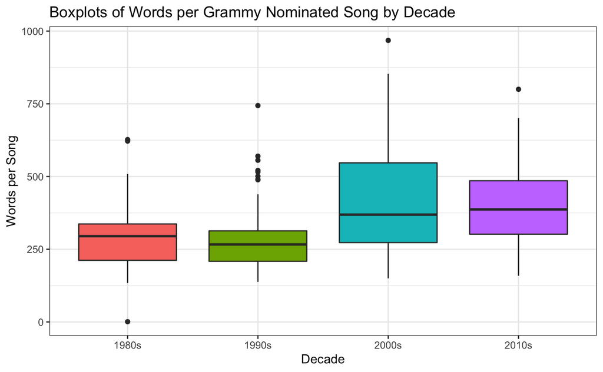

```r
WordsPerSong %>%
  ggplot() +
  aes(x = decade, y = count, fill = decade) +
  geom_boxplot() +
  labs(x = "Decade", y = "Words per Song", title = "Boxplots of Words per Grammy Nominated Song by Decade") +
  theme_bw() +
  theme(legend.position="none")
```

In the 1980s and 1990s, Grammy-nominated songs were generally close together in the number of words that were in each song. The songs nominated in the 2000s varied much greater in words per song than in the decades prior; it also included a song with the most words out of all the decades. In the 2010s, the variety decreased a bit, but it was still greater than in the 1980s and 1990s. Additionally, in general, Grammy-nominated songs have at least 125 words.

##### 2) Top ten words overall

```r
TopTen <-
  SigLyricWords %>%
  group_by(word) %>%
  summarise(count = n()) %>% #counts the number of times a word appears over all songs in every decade
  top_n(10) #keeps only the top 10 results

TopTen
```

| word | count |
| --- | --- |
| baby | 254 |
| feel | 147 |
| heart | 130 |
| life | 123 |
| love | 510 |
| night | 164 |
| shake | 104 |
| time | 133 |
| wanna | 154 |
| world | 103 |

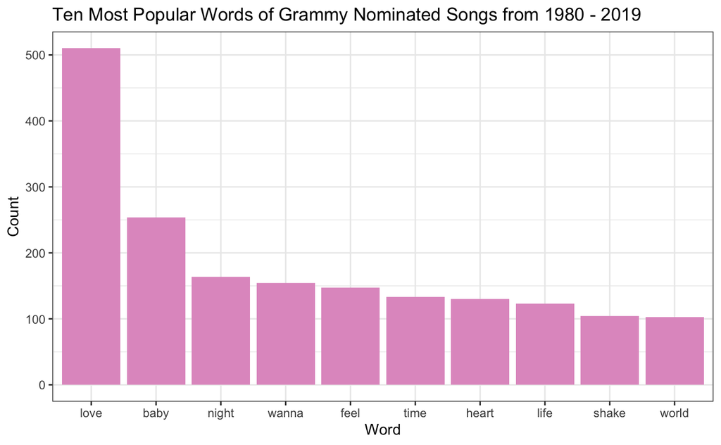

```r
TopTen %>%
  mutate(word = fct_reorder(word, desc(count))) %>% #puts the words in descending order
  ggplot() +
  aes(x = word, weight = count) +
  geom_bar(fill = "#e19bc8") +
  labs(x = "Word", y = "Count", title = "Ten Most Popular Words of Grammy Nominated Songs from 1980 - 2019") +
 theme_bw()
```

This graph shows that “love” is by far the most popular word used in Grammy-nominated songs. It has double the number of mentions as number two word “baby.” Other popular words to use surround the concept of being in love, like “baby,” “feel,” and “heart.”

##### 3) Top ten words by decade

```r
Top80s <-
  SigLyricWords %>%
  filter(decade == "1980s") %>% #keeps only words from songs nominated in the 80s
  group_by(word) %>%
  summarise(count = n()) %>% #counts the number of times a word appears in songs across the decade
  top_n(10) %>% #keeps only the top 10 results
  mutate(word = fct_reorder(word, desc(count))) %>% #puts the words in descending order for the following graph
  ggplot() + #creates the graph for the 80s list
  aes(x = word, weight = count) +
  geom_bar(fill = "#fa756a") +
  labs(x = "Word", y = "Count", title = "1980s") +
  theme_bw() +
  theme(axis.text.x = element_text(angle = 30, hjust = 1)) #tilts the axis tick labels to make the words more readable
```

```r
Top90s <-
  SigLyricWords %>%
  filter(decade == "1990s") %>%
  group_by(word) %>%
  summarise(count = n()) %>%
  top_n(10) %>%
  mutate(word = fct_reorder(word, desc(count))) %>%
  ggplot() +
  aes(x = word, weight = count) +
  geom_bar(fill = "#7bb000") +
  labs(x = "Word", y = "Count", title = "1990s") +
  theme_bw() +
  theme(axis.text.x = element_text(angle = 30, hjust = 1))
```

```r
Top00s <-
  SigLyricWords %>%
  filter(decade == "2000s") %>%
  group_by(word) %>%
  summarise(count = n()) %>%
  top_n(10) %>%
  mutate(word = fct_reorder(word, desc(count))) %>%
  ggplot() +
  aes(x = word, weight = count) +
  geom_bar(fill = "#00bfc5") +
  labs(x = "Word", y = "Count", title = "2000s") +
  theme_bw() +
  theme(axis.text.x = element_text(angle = 30, hjust = 1))
```

```r
Top10s <-
  SigLyricWords %>%
  filter(decade == "2010s") %>%
  group_by(word) %>%
  summarise(count = n()) %>%
  top_n(10) %>%
  mutate(word = fct_reorder(word, desc(count))) %>%
  ggplot() +
  aes(x = word, weight = count) +
  geom_bar(fill = "#c877ff") +
  labs(x = "Word", y = "Count", title = "2010s") +
  theme_bw() +
  theme(axis.text.x = element_text(angle = 30, hjust = 1))
```

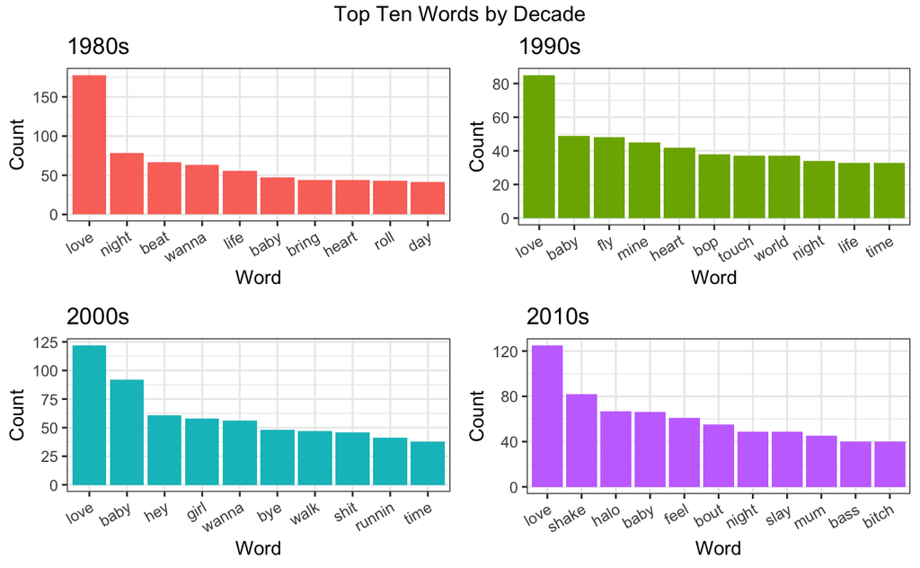

```r
grid.arrange(Top80s, Top90s, Top00s, Top10s, nrow = 2, top = "Top Ten Words by Decade") #arranges the four decades' graphs into a singular graphic with a title
```

These graphs show that “love” is consistently the most used word across Grammy-nominated songs. The only other consistent top word is “baby.” The appearances of interesting words “halo” and “slay” in the 2010s graph suggest that Beyonce has a tendency to repeat the same word over and over in her songs, since her songs “Halo” and “Formation” single-handedly contributed to the words’ appearances on the graph.

##### 4) Sentiment score

```r
NumSentiments <-
  sentiments %>%
  mutate(sentiment = gsub(pattern = "positive", replacement = "1", sentiment), #replaces positive with 1
         sentiment = gsub(pattern = "negative", replacement = "0", sentiment), #replaces negative with 0
         sentiment = as.integer(sentiment)) #makes the variable a numeric-type so that counts and means can be taken

SentimentScore <-
  SigLyricWords %>%
  full_join(NumSentiments, by="word") %>% #adds a sentiment score to all the eligible words in the Significant Lyrics table
  group_by(year, decade) %>% #keeps decade variable attached so that the mean sentiment across each decade can be taken later
  summarise(total=sum(sentiment, na.rm = TRUE)) %>% #adds up the net sentiments of each year
  drop_na() #removes a straggling row at the bottom, totaling all sentiments
```

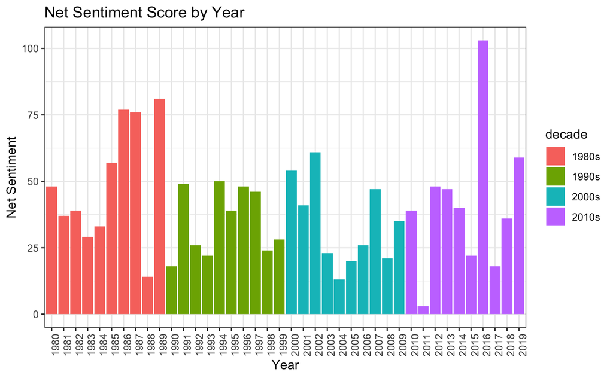

```r
SentimentScore %>%
  ggplot() +
  aes(x = year, fill = decade, weight = total) +
  geom_bar() +
  labs(x = "Year", y = "Net Sentiment", title = "Net Sentiment Score by Year") +
  theme_bw() +
  theme(axis.text.x = element_text(angle = 90, hjust = 1))
```

##### 5) Mean sentiment score

```r
MeanSentimentScore <-
  SentimentScore %>%
  group_by(decade) %>%
  summarise(mean = mean(total)) #calculates the mean sentiment in each decade
```

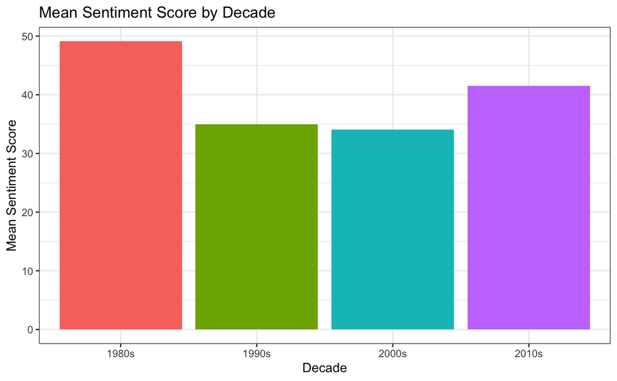

```r
MeanSentimentScore %>%
  ggplot() +
  aes(x = decade, fill = decade, weight = mean) +
  geom_bar() +
  labs(x = "Decade", y = "Mean Sentiment Score", title = "Mean Sentiment Score by Decade") +
  theme_bw() +
  theme(legend.position="none")
```

This graph shows that across the decades, the Grammys have not changed their preference for sad or happy songs to nominate. If anything, the songs have been a just a bit more dim since the 1980s, but the difference does not seem that great.

##### 6) Net setiment score regression line

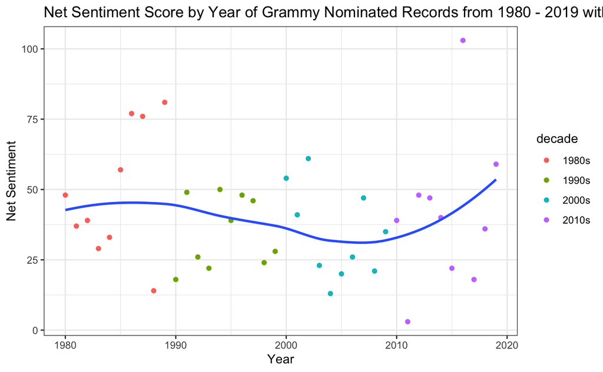

```r
ggplot(SentimentScore) +
  aes(x = year, y = total) +
  geom_point(aes(color = decade)) + #by containing color in the geom_point aes, it prevent the regression line from deisplaying as different colors
  geom_smooth(se=FALSE) + #se=FALSE removes the error bar from the typical geom_smooth graph
  labs(x = "Year", y = "Net Sentiment", title = "Net Sentiment Score by Year of Grammy Nominated Records from 1980 - 2019 with Linear Model Fit") +
  theme_bw() +
  scale_x_continuous(n.breaks = 5) #makes the graph only label five of the x axis ticks
```